# Data visualization

# Introduction

We already know how to extract useful information from data frames. Summary statistics describe data, but means, quantiles, and standard deviations alone may hide the *whole picture.*

Visualizations help us explore patterns, form hypotheses, and identify possible relationships between variables.

# Libraries

Install these packages once if needed, then load them before running the examples.

```r
# install.packages(c('tidyverse', 'patchwork', 'ggpubr'))
# install.packages('patchwork')
library(tidyverse)
```

# Working data

Today we will work with the **iris dataset**, included in R.

> This famous (Fisher’s or Anderson’s) iris data set gives the measurements in centimeters of the variables sepal length and width and petal length and width, respectively, for 50 flowers from each of 3 species of iris. The species are *Iris setosa*, *versicolor*, and *virginica*

```r
head(iris)
```

```
  Sepal.Length Sepal.Width Petal.Length Petal.Width Species
1          5.1         3.5          1.4         0.2  setosa
2          4.9         3.0          1.4         0.2  setosa
3          4.7         3.2          1.3         0.2  setosa
4          4.6         3.1          1.5         0.2  setosa
5          5.0         3.6          1.4         0.2  setosa
6          5.4         3.9          1.7         0.4  setosa
```

### Adding a categorical variable

Use `ifelse()` to classify lengths below 6 cm as short and the rest as long; `factor()` sets the category order.

```r
iris_df <- iris
iris_df$Sepal.Length.Category <- factor(
  ifelse(iris_df$Sepal.Length < 6, 'short', 'long'),
  levels = c('short', 'long')
)
iris_df |> head()
```

```
  Sepal.Length Sepal.Width Petal.Length Petal.Width Species
1          5.1         3.5          1.4         0.2  setosa
2          4.9         3.0          1.4         0.2  setosa
3          4.7         3.2          1.3         0.2  setosa
4          4.6         3.1          1.5         0.2  setosa
5          5.0         3.6          1.4         0.2  setosa
6          5.4         3.9          1.7         0.4  setosa
  Sepal.Length.Category
1                 short
2                 short
3                 short
4                 short
5                 short
6                 short
```

# Why visualize data?

**Summary table**

```r
iris_df |>
  group_by(Species) |>
  summarise(
    `Median Sepal Length` = median(Sepal.Length),
    `Median Petal Length` = median(Petal.Length)
  )
```

```
# A tibble: 3 × 3
  Species    `Median Sepal Length` `Median Petal Length`
  <fct>                      <dbl>                 <dbl>
1 setosa                       5                    1.5
2 versicolor                   5.9                  4.35
3 virginica                    6.5                  5.55
```

**Visualization**

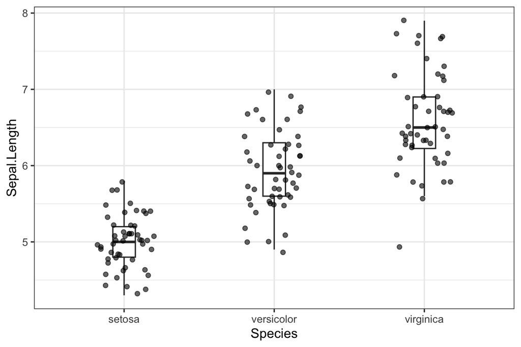

```r
ggplot(data = iris_df, aes(x = Species, y = Sepal.Length)) +
  geom_boxplot(width = 0.15, outlier.shape = NA) +
  geom_jitter(width = 0.2,  alpha = 0.6) +
  theme_bw()
```

Visualization reveals data structure and makes distribution shapes easier to understand.

**Plots help us explore data, form hypotheses, and spot problems or unexpected relationships.**

# Basic Visualization

## `plot()` – Numeric vs Numeric

A scatter plot displays points with x and y coordinates.

```r
x <- 1:10
y <- seq(2,20,2) ^ 2
x
```

```
 [1]  1  2  3  4  5  6  7  8  9 10
```

```r
y
```

```
 [1]   4  16  36  64 100 144 196 256 324 400
```

We consider that the x and y coordinates at the same positions in each of the vectors correspond to one particular point. So we have points (1,4), (2,16), (3,36), and so on.

- `seq(from_value, to_value, by_value)`- returns a vector with values from `from_value` to `to_value`with a step `by_value`

### Scatter plot

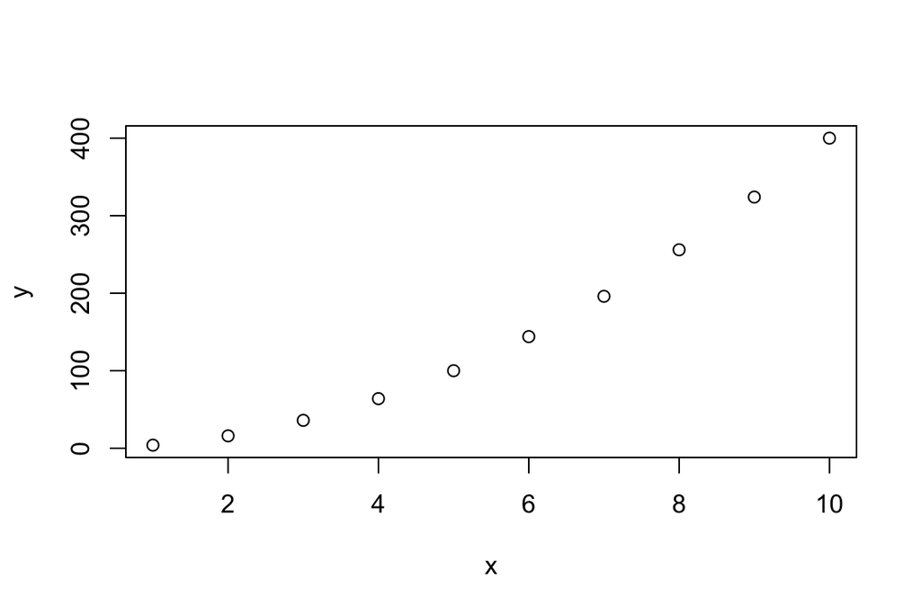

```r
plot(x, y)
```

### Sepal.Length vs Sepal.Width

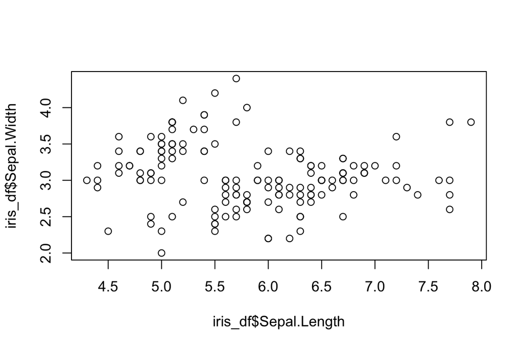

```r
plot(iris_df$Sepal.Length, iris_df$Sepal.Width)
```

We can make this graph prettier

```r
plot(iris_df$Sepal.Length, iris_df$Sepal.Width,
     main = "Sepal.Length vs. Sepal.Width", # the title
     xlab = "Sepal.Length", # Label of X-axis
     ylab = "Sepal.Width", # Label of Y-axis
     col = "blue", # color of plot
     pch = 19, # type of dots - 19 corresponds to the painted (solid) points
     cex = 1 # size of dots
     )
```

[output not shown]

### All plot() style parameters

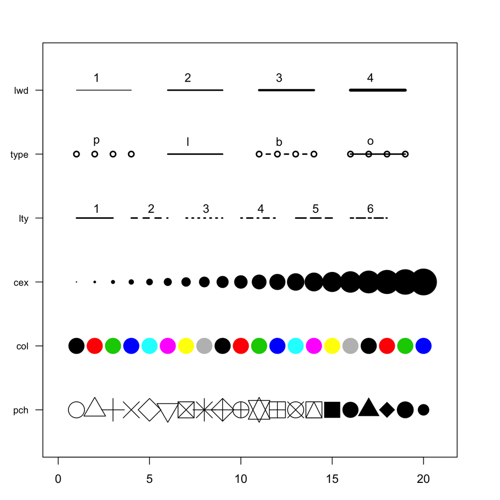

### Adding lines

By default `plot()` shows scatter plot, but we can change this behavior

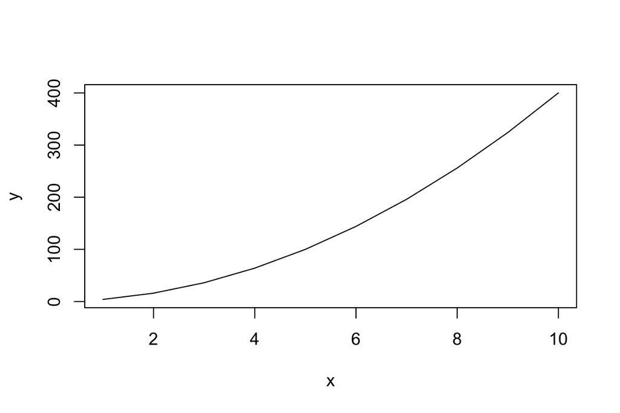

```r
plot(x, y,type = 'l')
```

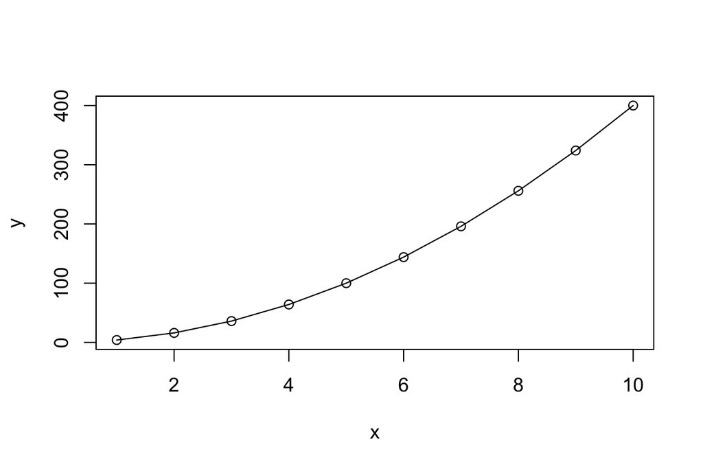

```r
plot(x, y, type = 'o')
```

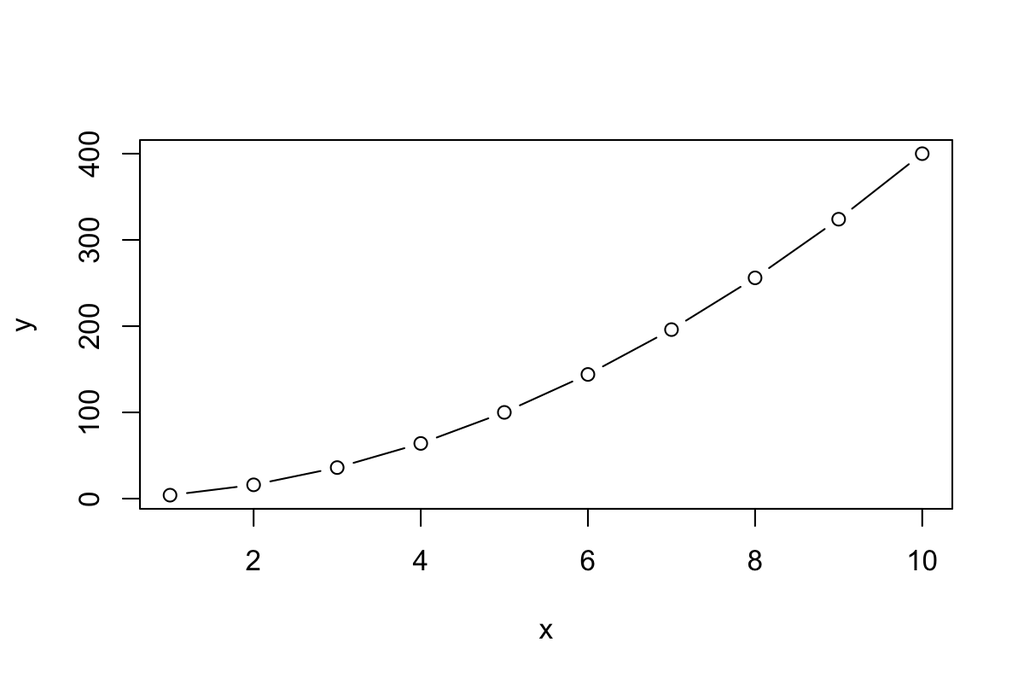

```r
plot(x, y,type = 'b')
```

> Show scatter with line width (lwd) = 3, point character (pch) = 2 and line type (lty) =3

```r
# Your code here
```

#### Terrible plot

Line graphs should sometimes be avoided, because **lines connect points in the order of their position in the vectors**

```r
x <- c(10,5,9,6,8,7,2,1,4,3)
y <- c(1:4, 6:8,5,10,9)
x
```

```
 [1] 10  5  9  6  8  7  2  1  4  3
```

```r
y
```

```
 [1]  1  2  3  4  6  7  8  5 10  9
```

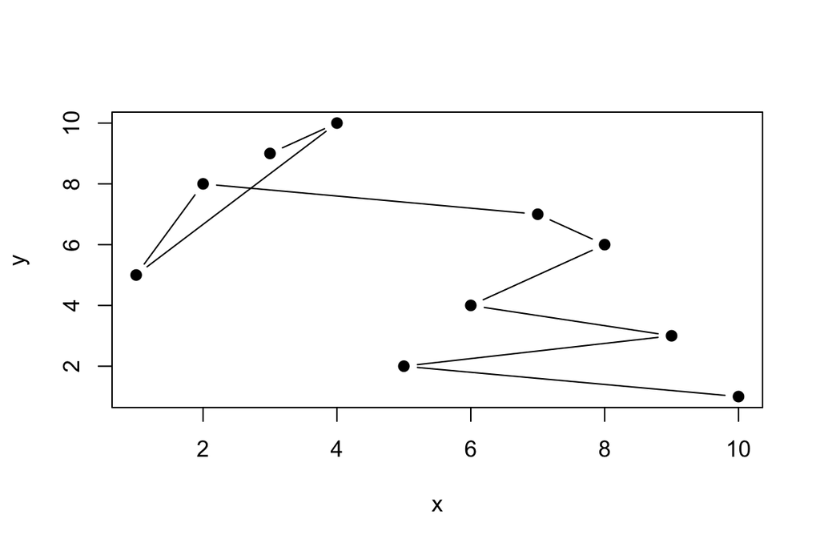

```r
plot(x, y, type = "b",  pch=19)
```

After sorting:

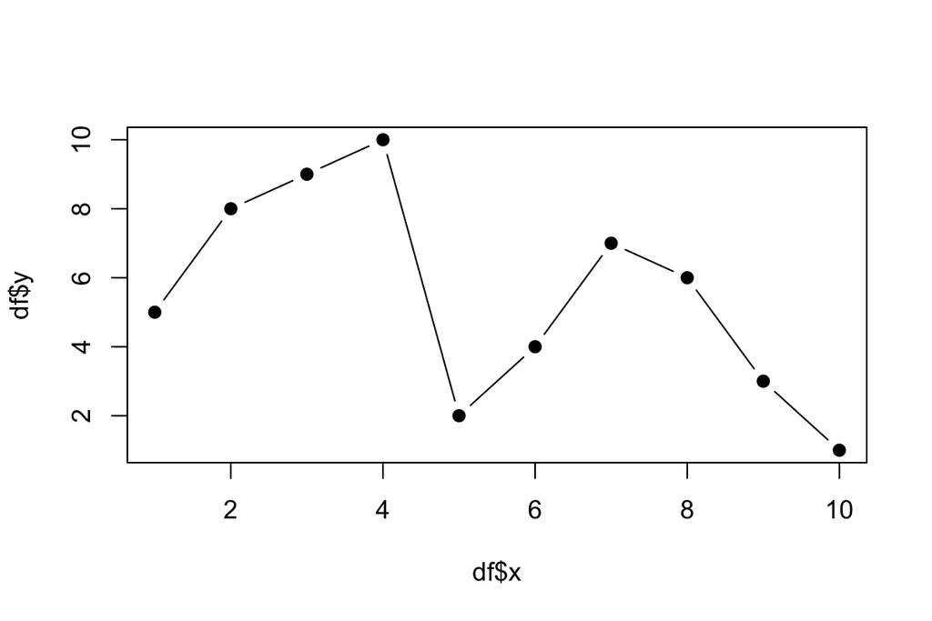

```r
df <- data.frame(x, y) |> arrange(x)
plot(df$x, df$y,type = "b", pch=19)
```

> *ggplot2 doesn’t have this problem.*

## `hist()` – Numeric distribution

- Uses one numeric variable: the x-axis shows values, and the y-axis shows counts or density.

### Distribution of Sepal.Length

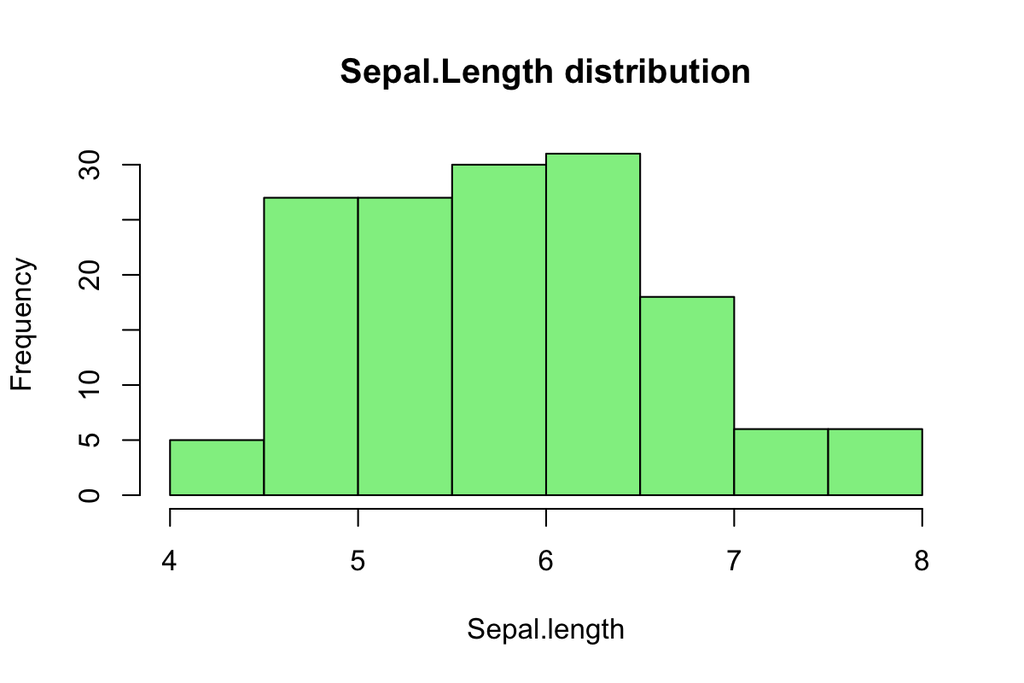

```r
hist(iris_df$Sepal.Length,
     main = "Sepal.Length distribution",
     xlab = "Sepal.length",
     col = "lightgreen",
     breaks = seq(4, 8, by = 0.5) # explicit interval boundaries
     )
```

Each bar counts observations in an interval. With these boundaries, the first interval includes values from 4 to 4.5. Changing the interval width can change the apparent shape of the distribution.

We can halve the interval width:

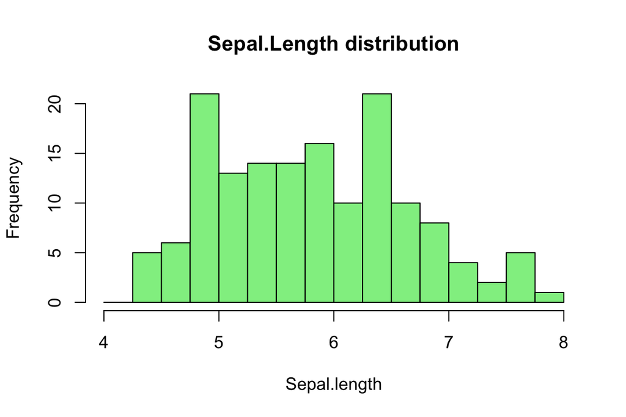

```r
hist(iris_df$Sepal.Length,
     main = "Sepal.Length distribution",
     xlab = "Sepal.length",
     col = "lightgreen",
     breaks = seq(4, 8, by = 0.25))
```

> Create histogram of Sepal.Width colored ‘lightblue’. Name the axis!

```r
# Your code here
```

A vertical line can mark the mean on a histogram:

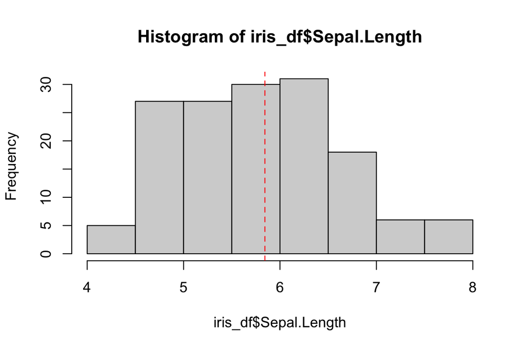

```r
hist(iris_df$Sepal.Length, breaks = seq(4, 8, by = 0.5))
abline(v = mean(iris_df$Sepal.Length), col = "red", lty = 2)
```

## `barplot()` – Categorical vs Numeric

```r
heights <- c(Roman = 190,
            Ann = 172,
            Charlie = 121,
            Vlad = 183,
            Sasha = 180) # named vector
heights
```

```
  Roman     Ann Charlie    Vlad   Sasha
    190     172     121     183     180
```

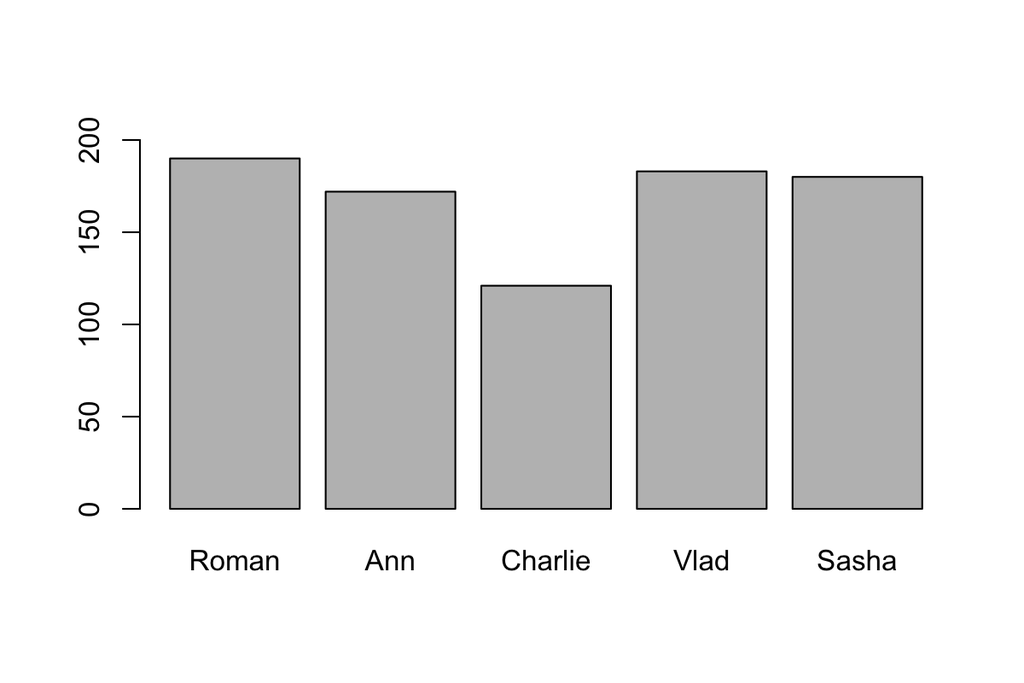

```r
barplot(heights, ylim = c(0,200))
```

> Sort (`sort()`) values and create barplot again

```r
# Your code here
```

We can customize this graph

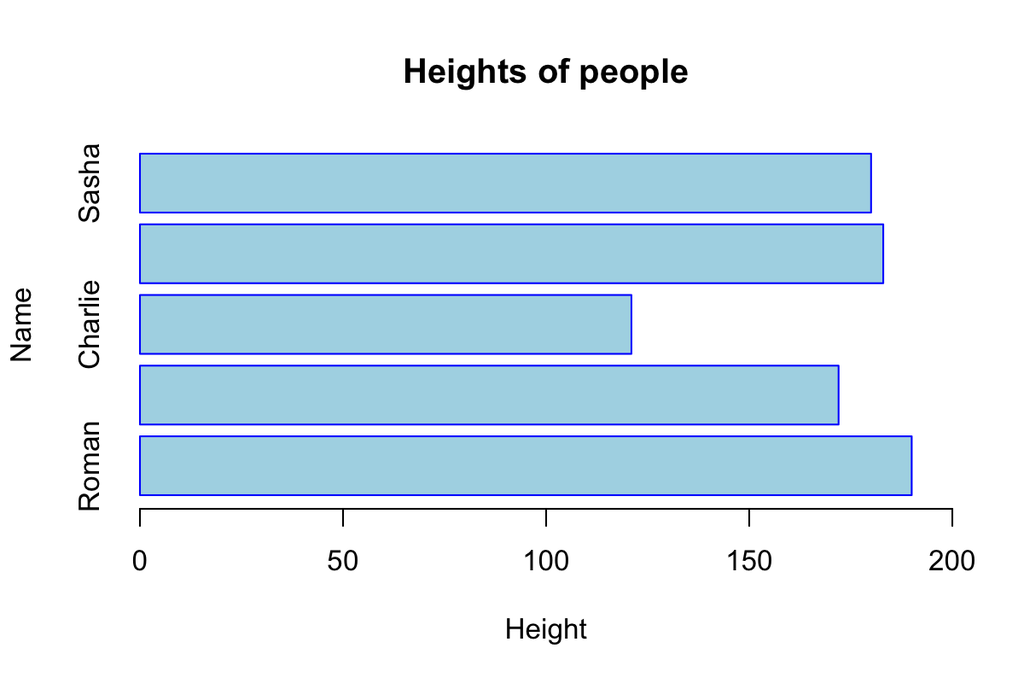

```r
barplot(heights,
        main = "Heights of people", # the title
        xlab = "Height", # Label of X-axis
        ylab = "Name", # Label of Y-axis
        col = "lightblue", # color of inner part of bars
        border = "blue", # color of borders
        horiz = TRUE, # make barplot horizontal
        xlim = c(0,200) # limits of values shown on x-axis
        )
```

### Number of observations per species

> Create `table()` of iris species and use it to make a barplot with color ‘violet’ Name the axis!

```r
# Your code here
```

Equal counts across species indicate that this dataset is **balanced by species**.

## `boxplot()` – Categorical vs Numeric distribution

Boxplots summarize the median, quartiles, and spread. Whiskers extend to the most extreme observations within 1.5 IQR of the box. Points beyond them are not necessarily errors.

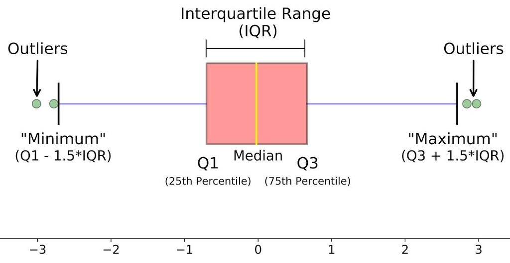

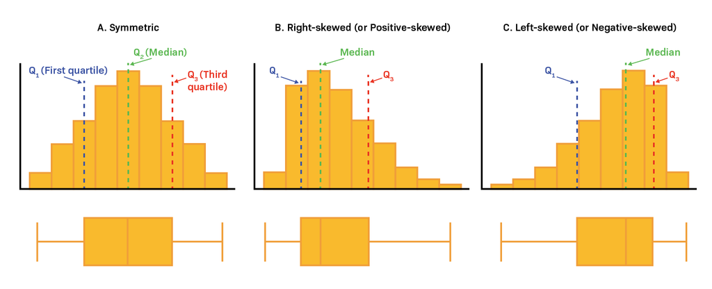

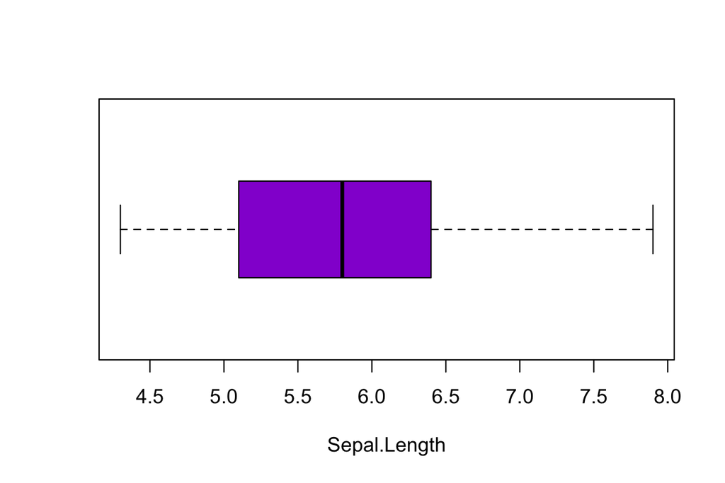

```r
boxplot(iris_df$Sepal.Length,
        # main = "Sepal.Length",
        ylab = "",
        xlab = "Sepal.Length",
        col = "darkviolet",
        horizontal = T)
```

### Grouped boxplots

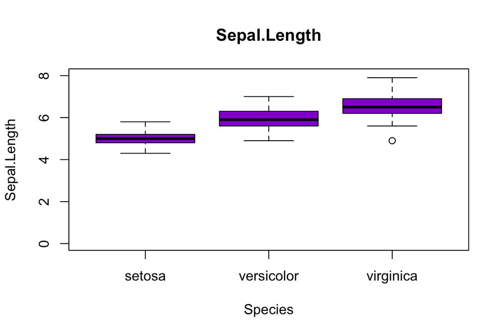

```r
boxplot(iris_df$Sepal.Length ~ iris_df$Species,
        main = "Sepal.Length",
        xlab = "Species",
        ylab = "Sepal.Length",
        col = "darkviolet",
        ylim = c(0,8),
        horizontal = F)
```

> Create boxplot of Sepal.Length grouped by Sepal.Length.Category. Name axis and let it be horizontal.

```r
# Your code here
```

Boxplots hide distribution shape, including multiple peaks. Add individual points or a density plot when shape matters.

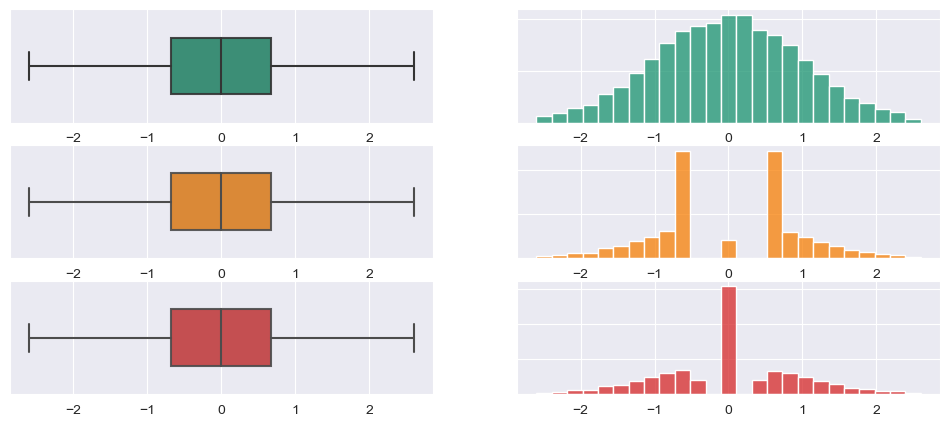

# `ggplot2`

**`ggplot2` is a widely used package for creating plots.**

## Philosophy

**A ggplot combines several components.**

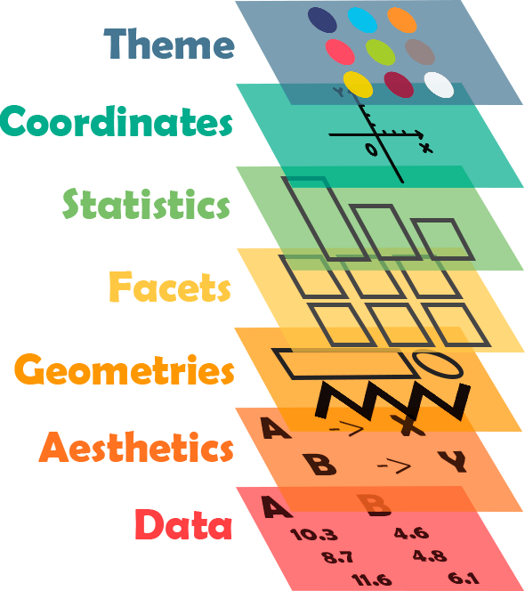

- **Data** provide the variables to display.
- **Aesthetics** (`aes()`) turn variable values into visual properties: position, color, size, shape, etc.
- **Geometries (geoms)** define how to show the data: as points, lines, bars, etc.
- **Facets** split the graph into panels (`facet_wrap()`, `facet_grid()`).
- **Statistics** transform or summarize data, for example by counting observations in histogram bins (`stat_bin()`).
- **Coordinates** control how positions are drawn (`coord_cartesian()`, `coord_polar()`).
- **Theme** styles backgrounds, grids, and text (`theme_bw()`, `theme()`).

```r
library(ggplot2)
```

## Layer basics

### 1. Data layer

Setting the data parameter inside `ggplot()`

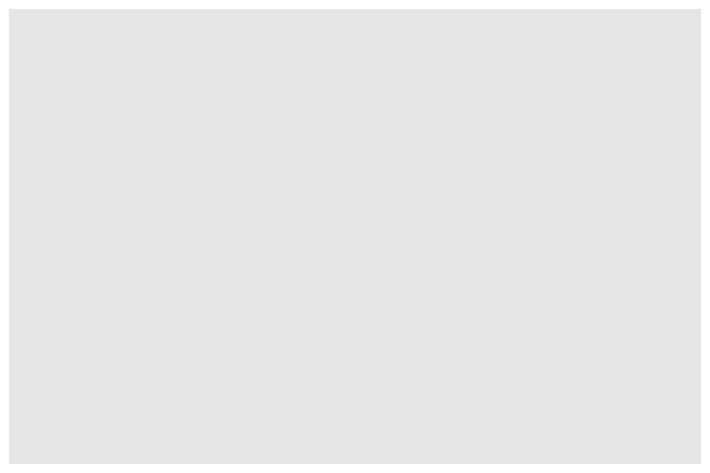

```r
ggplot(data=iris_df)
```

**There is nothing there! Because we did not specify what and how to visualize!**

### 2. Aesthetic mappings

Adding aesthetics using special function `aes()` inside `ggplot()`

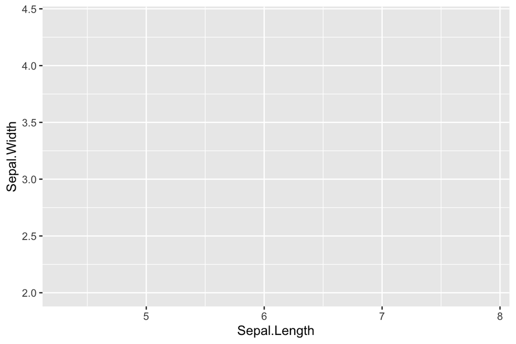

```r
ggplot(data=iris_df,
       mapping = aes(x=Sepal.Length, y=Sepal.Width))
```

There is ALMOST nothing there again! But here we set **aesthetics!** We specified which variables should be used and how *(Sepal.Length and Sepal.Width as X and Y axis).* But we did not set how to show data.

### 3. Geometry layer

Adding `geom_point()` to display each observation as a point at its mapped x and y positions.

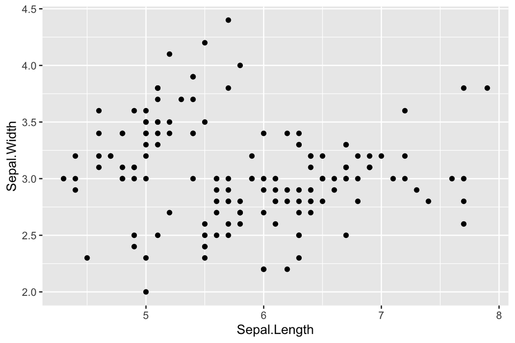

```r
ggplot(data=iris_df, mapping = aes(x=Sepal.Length, y=Sepal.Width)) +
  geom_point()
```

### 4. Theme

Add `theme_minimal()` to simplify the background and style the axes and text.

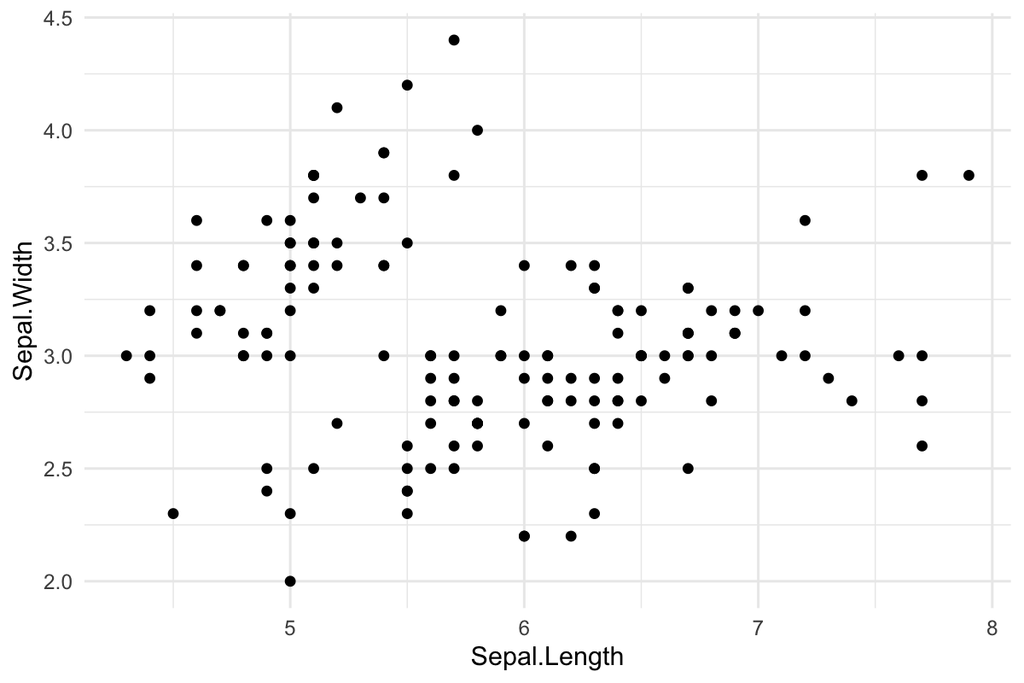

```r
ggplot(data=iris_df, mapping = aes(x=Sepal.Length, y=Sepal.Width)) +
  geom_point() +
  theme_minimal()
```

### 5. Facets

Facets allow us to split the plot into several panels according to some categorical (factor) variable.

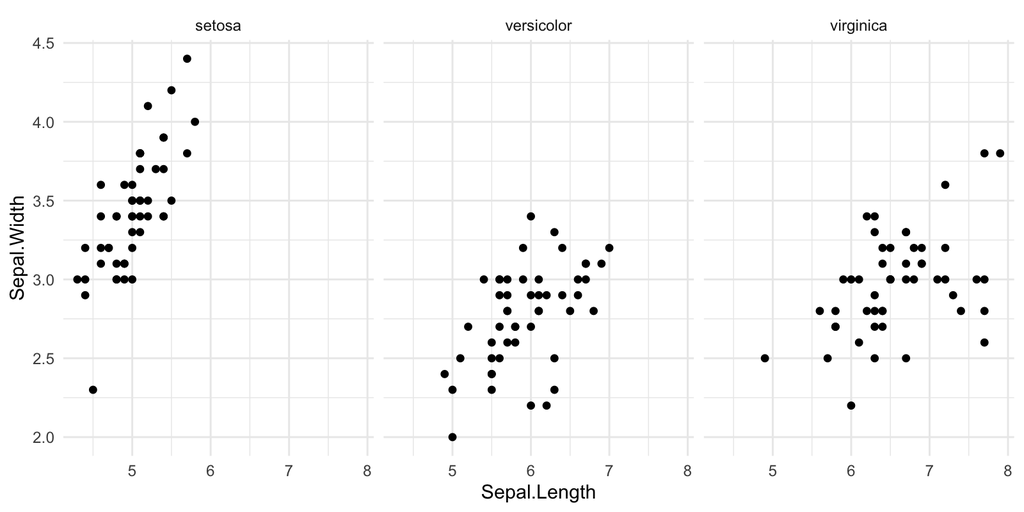

```r
ggplot(data = iris_df,
       mapping = aes(x = Sepal.Length, y = Sepal.Width)) +
  geom_point() +
  facet_wrap( ~ Species) +
  theme_minimal()
```

### **Obligatory layers to create chart:**

1. `ggplot(data=iris_df)` - **data**: `data.frame`, `tibble` …
2. `ggplot(..., mapping=aes(x=..., y=....))` - **aesthetic mappings**, here to x and y positions.
3. `+ geom_...()` - **geom**, at least one.

## Aesthetics

### Adding new aesthetics

Map categories to color or shape to distinguish groups, and numeric variables to size to show an additional measurement.

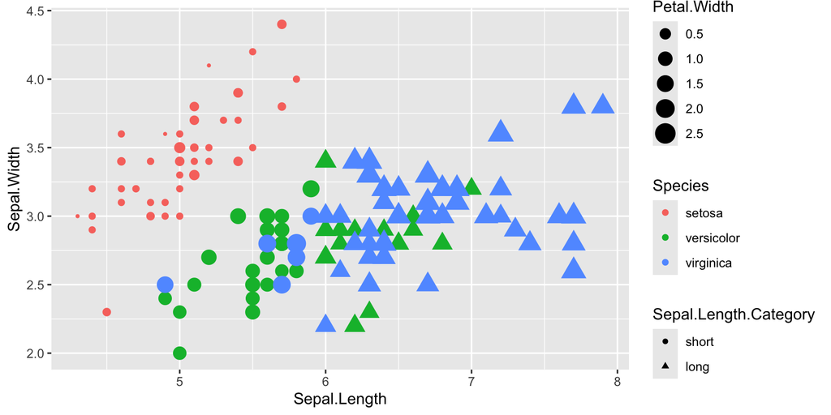

```r
#|
ggplot(data = iris_df,
       mapping = aes(
         x = Sepal.Length,
         y = Sepal.Width,
         color = Species,
         size = Petal.Width,
         shape=Sepal.Length.Category
       )) +
  geom_point()
```

### Some aesthetics:

- `color` - color
- `fill` - filling color
- `size` - size
- `shape` - shape of points
- `stroke` - stroke thickness
- `alpha` - transparency
- *other **specific for geoms** aesthetics…*

## Geometries

**Geoms have specific variables!**

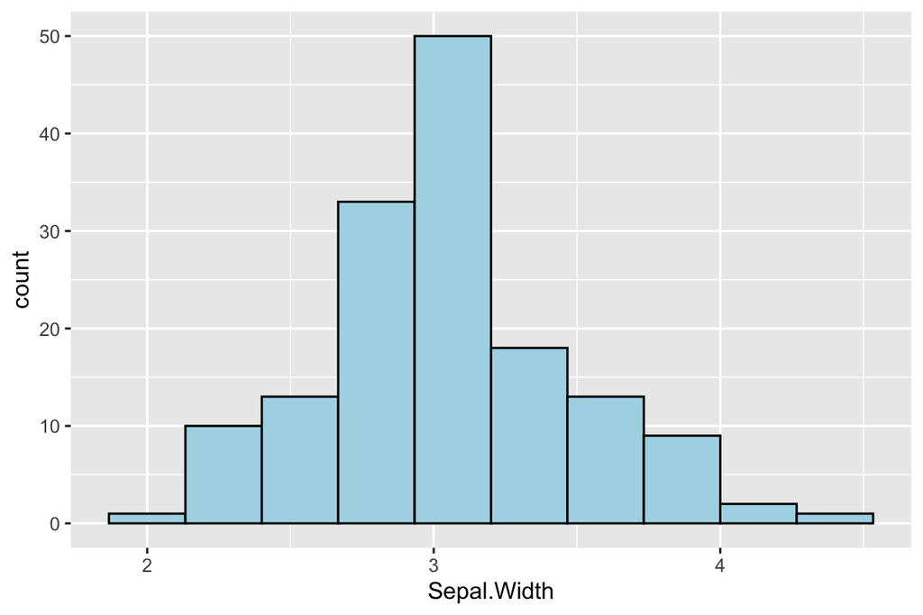

```r
iris_df |>
  ggplot(aes(x = Sepal.Width)) +
  geom_histogram(bins = 10,
                 fill = 'lightblue',
                 col = 'black')
```

### Adding several geoms

Add geoms with `+`. Later layers are drawn on top of earlier ones.

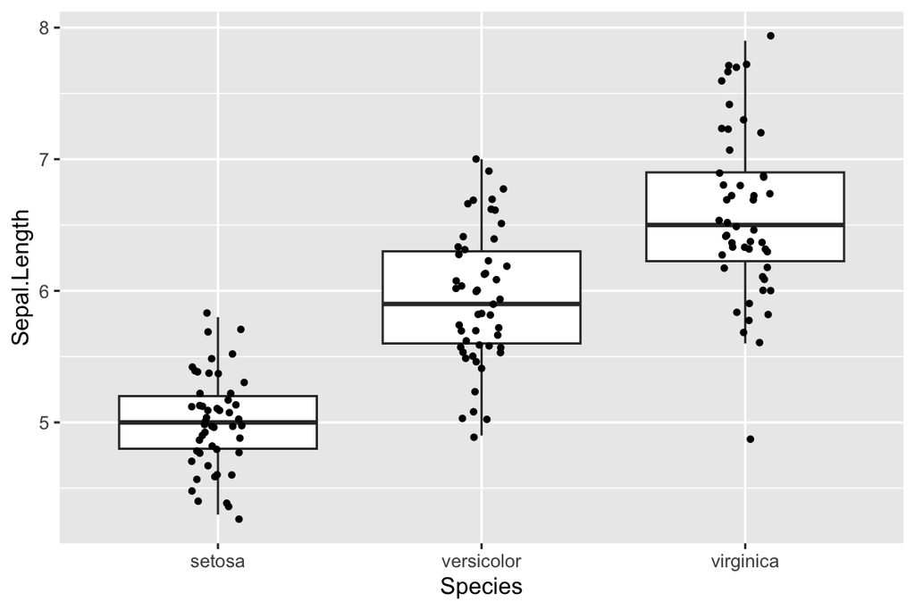

```r
iris_df |>
  ggplot(aes(x = Species,
             y = Sepal.Length)) +
  geom_boxplot(outliers = FALSE) +
  geom_jitter(width = 0.1, size = 1)
```

### Geoms can take different data!

Use `data =` inside a geom.

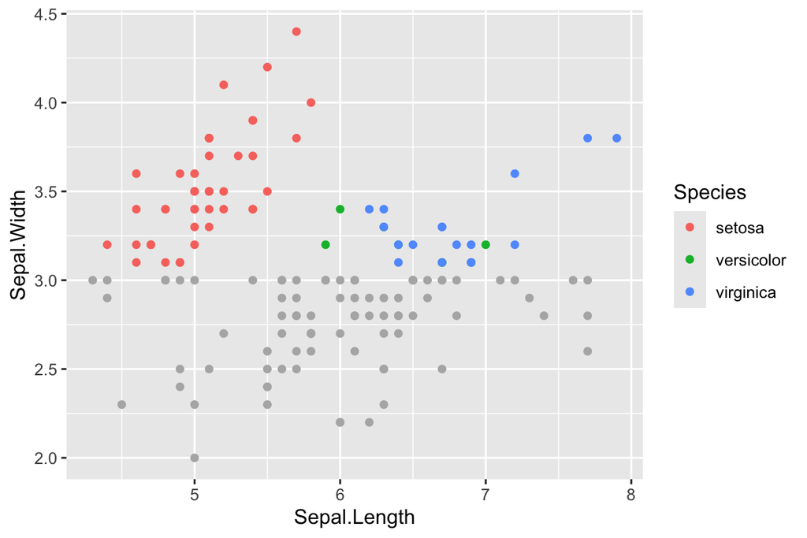

```r
iris_df |>
  ggplot(aes(x = Sepal.Length, y = Sepal.Width)) +
  geom_point(
    data = iris_df |> filter(Sepal.Width > 3),
    aes(color = Species)
  ) +
  geom_point(
    data = iris_df |> filter(Sepal.Width <= 3),
    color = "grey70"
  )
```

### Aesthetics inside geoms

- aesthetics inside `ggplot()` are set for **all geoms**
- aesthetics inside `geom_..()` functions are set only for this geom

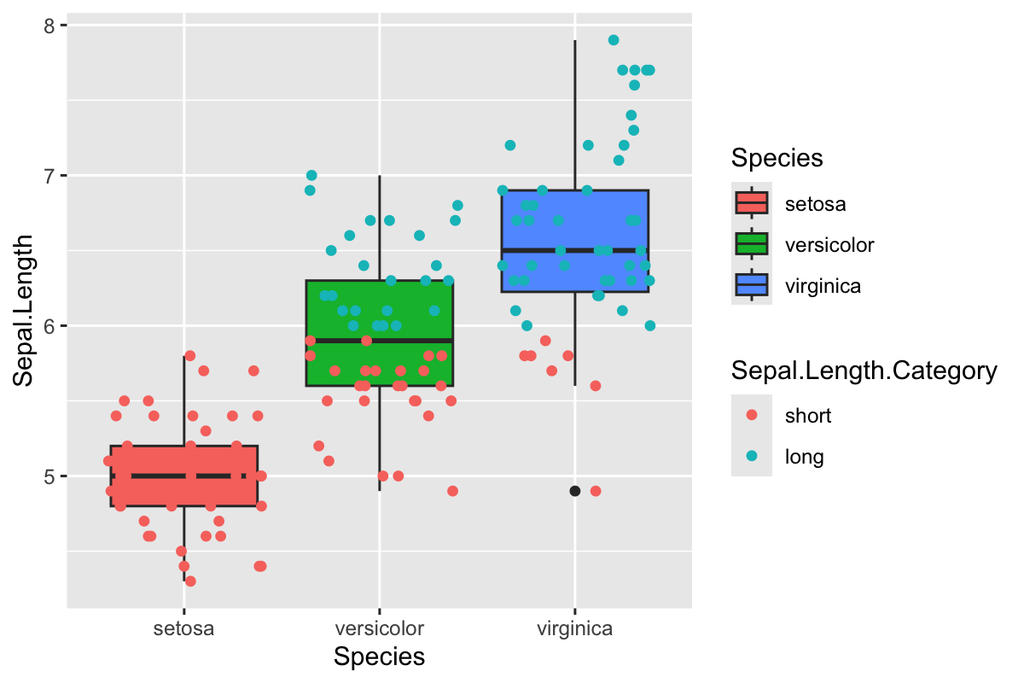

```r
iris_df |>
  ggplot(aes(x = Species, y = Sepal.Length)) +
  geom_boxplot(aes(fill = Species)) +
  geom_jitter(aes(color = Sepal.Length.Category), height = 0)
```